# Descriptive stats plots

# Plots

## Total number of complaints

Proportion complaints broken down by income bracket and then by income brakcet and borough:

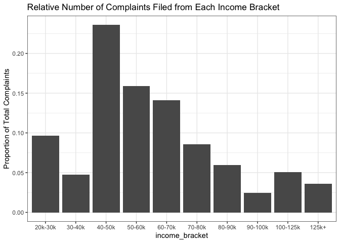

```r
nyc_plots %>%
    filter(!is.na(income_bracket)) %>%
    group_by(income_bracket) %>%
    summarize(n = n(),
              proportion = n/nrow(nyc_plots)) %>%
    ggplot(aes(x = income_bracket, y = proportion)) +
    geom_col() +
    ylab("Proportion of Total Complaints") +
    ggtitle("Relative Number of Complaints Filed from Each Income Bracket")
```

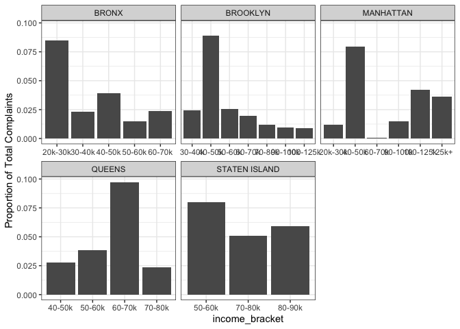

```r
nyc_plots %>%
    filter(!is.na(income_bracket)) %>%
    group_by(income_bracket, borough) %>%
    summarize(n = n(),
              proportion = n/nrow(nyc_plots)) %>%
    ggplot(aes(x = income_bracket, y = proportion)) +
    geom_col() +
    ylab("Proportion of Total Complaints") +
    facet_wrap(~borough, scales = "free_x")
```

Middle class income groups proportionally file the most complaints across all income brackets. The only exception is the Bronx, in which the proportion of 311 complaints is higher in the lowest income group.

Total complaints within each neighborhood of each borough:

[figure not shown]

```r
nyc_plots %>%
    filter(!is.na(area_name)) %>%
    group_by(area_name, borough) %>%
    summarize(n = n()) %>%
    ggplot(aes(x = area_name, y = n)) +
    geom_col() +
    ylab("Total Complaints") +
    xlab("Neighborhood") +
    theme(axis.text.x = element_text(angle = 60, hjust = 1)) +
    ggtitle("Complaints by Neighborhood") +
    facet_wrap(~borough, scales = "free_x")
```

Total number of `complaint_simp` broken down by each borough and income bracket:

Should I change this to median number?

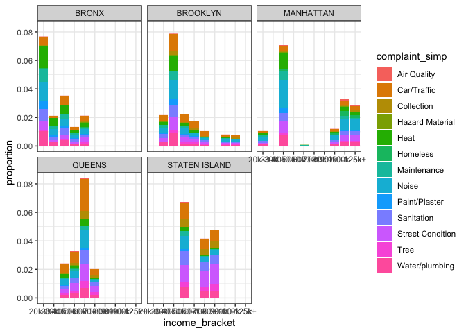

```r
nyc_plots %>%
    filter(!is.na(income_bracket),
           !is.na(complaint_simp)) %>%
    group_by(income_bracket, borough, complaint_simp) %>%
    summarize(n = n(),
              proportion = n/nrow(nyc_plots)) %>%
    ggplot(aes(x = income_bracket, y = proportion, fill = complaint_simp)) +
    geom_col() +
    facet_wrap(~borough)
```

# Proportion of unsolved cases by income bracket

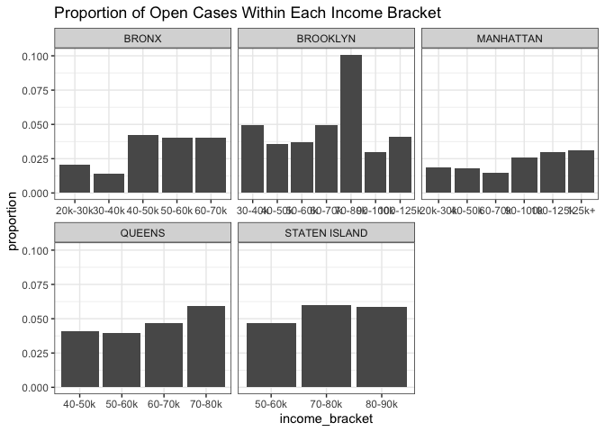

```r
p <- nyc_plots %>%
    filter(!is.na(income_bracket)) %>%
    group_by(income_bracket, borough, open_complaint) %>%
    summarize(n = n()) %>%
    pivot_wider(names_from = open_complaint, values_from = n) %>%
    rename(closed = '0',
           open = '1')

p %>% mutate(proportion = (open/closed)) %>%
    ggplot(aes(x = income_bracket, y = proportion)) +
    geom_col() +
    facet_wrap(~borough, scales = "free_x") +
    ggtitle("Proportion of Open Cases Within Each Income Bracket")
```

# Plots

#### Total number of complaints by income bracket

```r
# nyc_plots %>%
#     filter(!is.na(income_bracket)) %>%
#     group_by(income_bracket) %>%
#     summarize(n = n(),
#               proportion = n/nrow(nyc_plots)) %>%
#     ggplot(aes(x = income_bracket, y = proportion)) +
#     geom_col() +
#     ylab("Proportion of Total Complaints") +
#     ggtitle("Relative Number of Complaints Filed from Each Income Bracket")

nyc_plots %>%
    filter(!is.na(income_bracket)) %>%
    group_by(income_bracket, borough) %>%
    summarize(n = n(),
              proportion = n/nrow(nyc_plots)) %>%
    ggplot(aes(x = income_bracket, y = proportion, fill = income_bracket)) +
    geom_col() +
    ylab("Proportion") +
    xlab("Income Bracket") +
    ggtitle("Proportion of Total Complaints from Each Income Bracket") +
    facet_wrap(~borough, scales = "free_x") +
    theme(axis.text.x = element_text(angle = 60, hjust = 1))
```

[figure not shown]

Middle class income groups proportionally file the most complaints across all income brackets. The only exception is the Bronx, in which the proportion of 311 complaints is higher in the lowest income group.

#### Proportion of unsolved cases by income bracket

Proportion open:

```r
p <- nyc_plots %>%
    filter(!is.na(income_bracket)) %>%
    group_by(income_bracket, borough, open_complaint) %>%
    summarize(n = n()) %>%
    pivot_wider(names_from = open_complaint, values_from = n) %>%
    rename(closed = '0',
           open = '1')

p %>% mutate(proportion = (open/closed)) %>%
    ggplot(aes(x = income_bracket, y = proportion, fill = income_bracket)) +
    geom_col() +
    facet_wrap(~borough, scales = "free_x") +
    ggtitle("Proportion of Open Cases Within Each Income Bracket") +
    xlab("Income Bracket") +
    ylab("Proportion Open") +
    theme(axis.text.x = element_text(angle = 60, hjust = 1))
```

[figure not shown]

#### Total Health related complaints broken down by income bracket

```r
nyc_plots %>%
    filter(!is.na(income_bracket)) %>%
    group_by(income_bracket, borough, health_complaint) %>%
    summarize(n = n(),
              proportion = n/nrow(nyc_plots)) %>%
    ggplot(aes(x = income_bracket, y = proportion, fill = income_bracket)) +
    geom_col() +
    ylab("Proportion") +
    xlab("Income Bracket") +
    ggtitle("Proportion of Total Complaints from Each Income Bracket") +
    facet_wrap(~borough, scales = "free_x") +
    theme(axis.text.x = element_text(angle = 60, hjust = 1))
```

[figure not shown]

#### Proportion Health related complaints open broken down by income bracket:

```r
h <- nyc_plots %>%
    filter(!is.na(income_bracket),
           health_complaint == 1) %>%
    group_by(income_bracket, borough, open_complaint) %>%
    summarize(n = n()) %>%
    pivot_wider(names_from = open_complaint, values_from = n) %>%
    rename(closed = '0',
           open = '1')

h %>% mutate(proportion = (open/closed)) %>%
    ggplot(aes(x = income_bracket, y = proportion, fill = income_bracket)) +
    geom_col() +
    facet_wrap(~borough, scales = "free_x") +
    ggtitle("Proportion of Health Related Open Cases Within Each Income Bracket") +
    xlab("Income Bracket") +
    ylab("Proportion Open") +
    theme(axis.text.x = element_text(angle = 60, hjust = 1))
```

[figure not shown]

#### Median income of each complaint category:

```r
nyc_plots %>%
    filter(!is.na(median_income),
           !is.na(complaint_simp)) %>%
    mutate(complaint_simp = fct_reorder(complaint_simp, median_income)) %>%
    ggplot(aes(x = complaint_simp,
               y = (median_income/1000),
               fill = complaint_simp)) +
    geom_boxplot() +
    theme(axis.text.x = element_text(angle = 60, hjust = 1),
          legend.position = "none") +
    scale_y_continuous(breaks = scales::pretty_breaks(n = 10)) +
    ylab("Median Income (thousands)") +
    xlab("Complaint Category") +
    ggtitle("Median Income of Community District where Complaint Category Occurs")
```

[figure not shown]

```r
# open cases:

nyc_plots %>%
    filter(!is.na(median_income),
           !is.na(complaint_simp),
           open_complaint == 1) %>%
    ggplot(aes(x = complaint_simp,
               y = (median_income/1000),
               fill = complaint_simp)) +
    geom_boxplot() +
    theme(axis.text.x = element_text(angle = 60, hjust = 1),
          legend.position = "none") +
    scale_y_continuous(breaks = scales::pretty_breaks(n = 10)) +
    ylab("Median Income (thousands)") +
    xlab("Complaint Category") +
    ggtitle("Median Income of Community District where Open Complaint Category Occurs")
```

[figure not shown]

#### Not to be included:

Total complaints within each neighborhood of each borough:

```r
nyc_plots %>%
    filter(!is.na(area_name)) %>%
    group_by(area_name, borough) %>%
    summarize(n = n()) %>%
    ggplot(aes(x = area_name, y = n)) +
    geom_col() +
    ylab("Total Complaints") +
    xlab("Neighborhood") +
    theme(axis.text.x = element_text(angle = 60, hjust = 1)) +
    ggtitle("Complaints by Neighborhood") +
    facet_wrap(~borough, scales = "free_x")
```

[figure not shown]

```r
nyc_plots %>%
    filter(!is.na(community_board)) %>%
    group_by(community_board, borough) %>%
    summarize(n = n()) %>%
    filter(n > 100) %>%
    ggplot(aes(x = community_board, y = n)) +
    geom_col() +
    ylab("Total Complaints") +
    xlab("Community Board") +
    theme(axis.text.x = element_text(angle = 60, hjust = 1)) +
    ggtitle("Complaints by Community Board") +
    facet_wrap(~borough, scales = "free_x")
```

[figure not shown]

other med income plot:

```r
#
# nyc_plots %>%
#     filter(!is.na(income_bracket),
#            !is.na(complaint_simp)) %>%
#     group_by(income_bracket, borough, complaint_simp) %>%
#     summarize(n = n()) %>%
#     mutate(proportion = n/nrow(nyc_plots)) %>%
#     arrange(income_bracket, proportion) %>%
#     mutate(order = row_number()) %>%
#     group_by(complaint_simp) %>%
#     ggplot(aes(x = complaint_simp, y = proportion, fill = complaint_simp)) +
#     geom_col() +
#     facet_wrap(~income_bracket, scales = "free_x", ncol = 5) +
#     theme(axis.text.x = element_text(angle = 75, hjust = 1))
#

#
#            complaint_simp = fct_reorder(complaint_simp,
#                                         proportion,
#                                         .desc = TRUE)) %>%
```

- number unsolved (open) cases versus income bracket - look at health complaints.
- number of unsolved (open) cases within each neighborhood with color representing proportion black, hispanic

# Final Plots:

## Proportion of unsolved cases by income bracket

```r
p <- nyc_plots %>%
    filter(!is.na(income_bracket)) %>%
    group_by(income_bracket, borough, open_complaint) %>%
    summarize(n = n()) %>%
    pivot_wider(names_from = open_complaint, values_from = n) %>%
    rename(closed = '0',
           open = '1')

p %>% mutate(proportion = (open/closed)) %>%
    ggplot(aes(x = income_bracket, y = proportion, fill = income_bracket)) +
    geom_col() +
    facet_wrap(~borough, scales = "free_x") +
    ggtitle("Proportion of Open Cases Within Each Income Bracket") +
    xlab("Income Bracket") +
    ylab("Proportion Open") +
    theme(axis.text.x = element_text(angle = 60, hjust = 1))
```

[figure not shown]

## Median income of each complaint category:

```r
nyc_plots %>%
    filter(!is.na(median_income),
           !is.na(complaint_simp)) %>%
    mutate(complaint_simp = fct_reorder(complaint_simp, median_income)) %>%
    ggplot(aes(x = complaint_simp,
               y = (median_income/1000),
               fill = complaint_simp)) +
    geom_boxplot() +
    theme(axis.text.x = element_text(angle = 60, hjust = 1),
          legend.position = "none") +
    scale_y_continuous(breaks = scales::pretty_breaks(n = 10)) +
    ylab("Median Income (thousands)") +
    xlab("Complaint Category") +
    ggtitle("Median Income of Community District where Complaint Category Occurs")
```

[figure not shown]

## plot of percent race plotted against proportion open:

```r
r <- nyc_plots %>%
    pivot_longer(cols = per_black_nh:per_other, names_to = "race", values_to = "percent_pop") %>%
    filter(!is.na(race),
           !is.na(percent_pop)) %>%
    group_by(race, borough, percent_pop, open_complaint) %>%
    summarize(n = n()) %>%
    pivot_wider(names_from = open_complaint, values_from = n) %>%
    rename(closed = '0',
           open = '1')

r %>% mutate(proportion = (open/(open + closed))) %>%
    ggplot(aes(x = percent_pop, y = proportion, color = race)) +
    geom_point() +
    geom_smooth(se = FALSE) +
    xlab("Percentage of Community District Population") +
    ylab("Proportion Open") +
    ggtitle("Unresolved Complaints as a Function of Neighborhood Population")
```

[figure not shown]

density plot of number of days to close by income group or pop proportions?